# Final report

### Does the runtime of the movie affect the predicting vars?

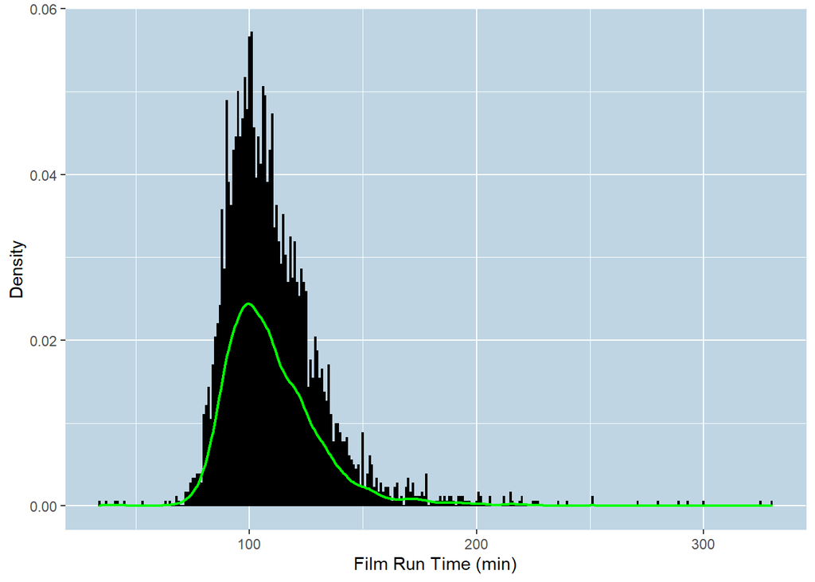

```r
ggplot(data = movies, aes(x = duration)) +
geom_histogram(binwidth = 0.5, color="black", fill="pink", alpha=1,
             aes(y=..density..), alpha=1) + geom_density(lwd = 0.8, color = "green") +
             xlab("Film Run Time (min)") + ylab("Density") +
  bgcolor("#BFD5E3")+
  border("#BFD5E3")
```

[figure not shown]

```r
p1 = ggplot(movies, aes(duration, imdb_score,color = as.factor(winner) ))+
  geom_jitter(width = 0.1, height = 0.1, alpha = 0.75)+
  geom_smooth(se=FALSE)+
  labs(x = "Runtime (min)", y = "IMDB score" , color='Winner') +
  bgcolor("#BFD5E3")+
  border("#BFD5E3")

p2 = ggplot(movies, aes(duration, gross,color = as.factor(winner)))+
  geom_jitter(width = 0.1, height = 0.1, alpha = 0.75)+
  geom_smooth(se=FALSE)+
  labs(x = "Runtime (min)",y = "Gross" , color='Winner') +
  bgcolor("#BFD5E3")+
  border("#BFD5E3")

ggarrange(p1, p2,nrow = 2)
```

### Does the new variables affect the predicting vars?

[figure not shown]

```r
p1 = ggplot(movies, aes(x=avg_act_gross/1000000, y=gross/1000000, shape = as.factor(winner),color = as.factor(winner))) +
  geom_point() +
  labs(title = "movie gross", subtitle = "by main actor average gross", x = "avg actor gross(in millions)", y = "movie gross(in millions)", color='Winner',shape = "Winner")+scale_colour_manual(values = c("gold3", "dark red"))+
  geom_smooth()

p2 = ggplot(movies, aes(x=avg_act_rating, y=imdb_score, color = as.factor(winner), shape = as.factor(winner))) +
  geom_point() +
  labs(title = "movie rating", subtitle ="by main actor average rating",  x = "avg actor IMDB rating", y = "movie IMDB rating", color='Winner',shape = "Winner")+scale_colour_manual(values = c("gold3", "dark red"))+
  geom_smooth()

p3 = ggplot(movies, aes(x=avg_dir_gross/1000000, y=gross/1000000, color = as.factor(winner), shape = as.factor(winner))) +
  geom_point() +
  labs(title = "movie gross", subtitle ="by director average gross", x = "avg director gross(in millions)", y = "movie gross(in millions)", color='Winner',shape = "Winner")+ scale_colour_manual(values = c("gold3", "dark red"))+
 geom_smooth()

p4 = ggplot(movies, aes(x=avg_dir_rating, y=imdb_score, color = as.factor(winner), shape = as.factor(winner))) +
  geom_point() +
  labs(title = "movie rating", subtitle = "by director average rating", x = "avg director IMDB rating", y = "movie IMDB rating", color='Winner',shape = "Winner" ) + scale_colour_manual(values = c("gold3", "dark red"))+
  geom_smooth()


ggarrange(p1, p2,p3,p4, widths = c(10,10,10,10))
```

We can see from the plot above there is kind of linear connection between our new vars and IMDB score.

### Connection actor director

```r
glimpse(movies)
```

```
## Rows: 3,639
## Columns: 24
## $ movie_title               <chr> "\303†on Flux", "10 Cloverfield Lane", "10 D~
## $ director_name             <chr> "Karyn Kusama", "Dan Trachtenberg", "Timothy~
## $ num_critic_for_reviews    <int> 178, 411, 1, 133, 84, 26, 113, 597, 450, 119~
## $ duration                  <int> 93, 104, 111, 97, 100, 107, 108, 134, 94, 98~
## $ director_facebook_likes   <int> 45, 16, 0, 19, 36, 53, 212, 0, 0, 56, 0, 17,~
## $ main_actor_facebook_likes <int> 9000, 14000, 1000, 23000, 2000, 954, 969, 20~
## $ gross                     <int> 25857987, 71897215, 14616, 38176108, 6694155~
## $ genres                    <chr> "Action", "Drama", "Drama", "Comedy", "Adven~
## $ main_actor                <chr> "Charlize Theron", "Bradley Cooper", "Christ~
## $ num_voted_users           <int> 110614, 126893, 314, 222099, 26413, 5557, 22~
## $ cast_total_facebook_likes <int> 10185, 14504, 2059, 37907, 4182, 2512, 2799,~
## $ content_rating            <chr> "PG-13", "PG-13", "R", "PG-13", "G", "R", "P~
## $ budget                    <dbl> 6.2e+07, 1.5e+07, 1.2e+07, 1.6e+07, 8.5e+07,~
## $ title_year                <int> 2005, 2016, 2015, 1999, 2000, 2006, 2009, 20~
## $ imdb_score                <dbl> 5.5, 7.3, 7.5, 7.2, 4.8, 6.4, 5.6, 8.1, 7.6,~
## $ movie_facebook_likes      <int> 0, 33000, 26000, 10000, 372, 294, 0, 83000, ~
## $ avg_dir_rating            <dbl> 5.5, 7.3, 7.5, 7.2, 4.8, 6.4, 5.9, 7.7, 7.6,~
## $ avg_dir_gross             <dbl> 25857987, 71897215, 14616, 38176108, 6694155~
## $ avg_act_rating            <dbl> 6.1, 6.5, 6.0, 6.4, 4.8, 6.3, 5.6, 7.7, 6.9,~
## $ avg_act_gross             <dbl> 27039542, 127562714, 22587625, 41505410, 669~
## $ month                     <int> 2, 3, 11, 7, 3, 4, 3, 1, 4, 7, 3, 4, 4, 4, 9~
## $ winner                    <dbl> 0, 0, 0, 0, 0, 0, 0, 1, 0, 0, 0, 0, 0, 0, 0,~
## $ ROI                       <dbl> 0.417064306, 4.793147667, 0.001218000, 2.386~
## $ budgetclass               <fct> high budget, medium budget, medium budget, m~
```

#### most common due

```r
dir_act = movies

dir_act$count = 1


dir_act = dir_act %>%
  group_by(director_name, main_actor) %>%
  summarise(join_movies=sum(count),
            g_mean=(mean(gross)),imdb_mean=(mean(imdb_score)) ,winner_sum=(sum(winner)),  .groups = 'drop')

dir_act <-dir_act[order(-dir_act$g_mean),] %>% filter(join_movies > 1)



# top_dir_act
m_common = dir_act %>% filter(join_movies==max(dir_act$join_movies))
print(paste("is most common due is:" ,m_common$director_name,"and",m_common$main_actor, "with",m_common$join_movies, "joint movies together" ))
```

```
## [1] "is most common due is: Clint Eastwood and Clint Eastwood with 8 joint movies together"
```

```r
dir_act
```

```
## # A tibble: 237 x 6
##    director_name    main_actor         join_movies   g_mean imdb_mean winner_sum
##    <chr>            <chr>                    <dbl>    <dbl>     <dbl>      <dbl>
##  1 Joss Whedon      Chris Hemsworth              3   5.69e8      7.9           0
##  2 George Lucas     Natalie Portman              3   3.88e8      6.93          0
##  3 Michael Bay      Glenn Morshower              2   3.77e8      6.15          0
##  4 Jon Favreau      Scarlett Johansson           2   3.63e8      7.8           2
##  5 Francis Lawrence Jennifer Lawrence            3   3.48e8      6.97          0
##  6 Peter Jackson    Christopher Lee              2   3.27e8      8.75          2
##  7 Jon Favreau      Robert Downey Jr.            2   3.15e8      7.45          0
##  8 Zack Snyder      Henry Cavill                 2   3.11e8      7.05          0
##  9 Pierre Coffin    Steve Carell                 2   3.10e8      7.6           0
## 10 Sam Mendes       Albert Finney                2   3.04e8      7.8           2
## # ... with 227 more rows
```

#### top gross / imdb/Oscar winners leading dues:

```r
top_dir_act_g <- head(arrange(dir_act, desc(g_mean)), n = 10)


top_dir_act_g
```

```
## # A tibble: 10 x 6
##    director_name    main_actor         join_movies   g_mean imdb_mean winner_sum
##    <chr>            <chr>                    <dbl>    <dbl>     <dbl>      <dbl>
##  1 Joss Whedon      Chris Hemsworth              3   5.69e8      7.9           0
##  2 George Lucas     Natalie Portman              3   3.88e8      6.93          0
##  3 Michael Bay      Glenn Morshower              2   3.77e8      6.15          0
##  4 Jon Favreau      Scarlett Johansson           2   3.63e8      7.8           2
##  5 Francis Lawrence Jennifer Lawrence            3   3.48e8      6.97          0
##  6 Peter Jackson    Christopher Lee              2   3.27e8      8.75          2
##  7 Jon Favreau      Robert Downey Jr.            2   3.15e8      7.45          0
##  8 Zack Snyder      Henry Cavill                 2   3.11e8      7.05          0
##  9 Pierre Coffin    Steve Carell                 2   3.10e8      7.6           0
## 10 Sam Mendes       Albert Finney                2   3.04e8      7.8           2
```

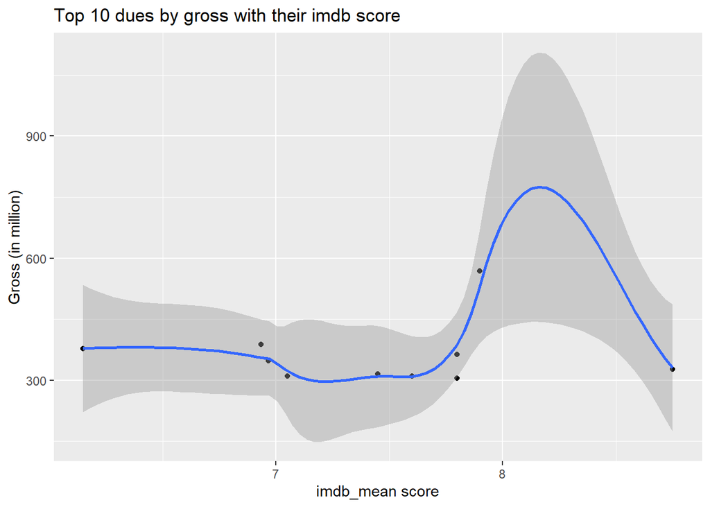

```r
top_dir_act_g %>%
  arrange(desc(g_mean)) %>%
  top_n(10, g_mean) %>%
  ggplot(aes(x=imdb_mean, y=g_mean/1000000)) +
  geom_point( ) +
  geom_smooth() +
  labs(x = "imdb_mean score", y = "Gross (in million)", title = "Top 10 dues by gross with their imdb score")
```

[figure not shown]

```r
top_dir_act_imdb <- head(arrange(dir_act, desc(imdb_mean)), n = 10)


top_dir_act_imdb %>%
  arrange(desc(g_mean)) %>%
  top_n(10, g_mean) %>%
  ggplot(aes(x=g_mean, y=g_mean)) +
  geom_point(aes(color= as.factor(join_movies),size= as.factor(join_movies)) ) +
  geom_smooth() +

  labs(x = "Imdb_mean score", y = "Gross (in million)", title = "Top 10 dues by gross with their imdb score",color="join_movies",size= "join_movies")
```

```r
top_dir_act_imdb
```

```
## # A tibble: 10 x 6
##    director_name        main_actor      join_movies  g_mean imdb_mean winner_sum
##    <chr>                <chr>                 <dbl>   <dbl>     <dbl>      <dbl>
##  1 Peter Jackson        Christopher Lee           2  3.27e8      8.75          2
##  2 Christopher Nolan    Christian Bale            3  2.64e8      8.6           1
##  3 Francis Ford Coppola Al Pacino                 2  1.01e8      8.4           1
##  4 David Fincher        Brad Pitt                 2  8.23e7      8.3           1
##  5 Guy Ritchie          Jason Statham             3  2.13e7      8.27          0
##  6 John Lasseter        Tom Hanks                 2  2.19e8      8.1           0
##  7 George Lucas         Harrison Ford             2  2.88e8      8.1           0
##  8 Dean DeBlois         Gerard Butler             2  1.97e8      8.05          0
##  9 Chan-wook Park       Min-sik Choi              2  1.20e6      8.05          0
## 10 James Cameron        Michael Biehn             3  5.93e7      8.03          2
```

```r
top_dir_act_w <- head(arrange(dir_act, desc(winner_sum)), n = 10)

top_dir_act_w
```

```
## # A tibble: 10 x 6
##    director_name    main_actor         join_movies   g_mean imdb_mean winner_sum
##    <chr>            <chr>                    <dbl>    <dbl>     <dbl>      <dbl>
##  1 Steven Spielberg Harrison Ford                4   2.34e8      7.65          3
##  2 Peter Jackson    Naomi Watts                  3   2.18e8      7.2           3
##  3 Tim Burton       Johnny Depp                  6   1.69e8      6.87          3
##  4 Jon Favreau      Scarlett Johansson           2   3.63e8      7.8           2
##  5 Peter Jackson    Christopher Lee              2   3.27e8      8.75          2
##  6 Sam Mendes       Albert Finney                2   3.04e8      7.8           2
##  7 Gore Verbinski   Johnny Depp                  5   2.50e8      7.24          2
##  8 Steven Spielberg Tom Hanks                    3   1.22e8      7.83          2
##  9 Paul Verhoeven   Ronny Cox                    2   1.19e8      7.5           2
## 10 Baz Luhrmann     Leonardo DiCaprio            3   1.12e8      7.13          2
```

[figure not shown]

```r
top_dir_act_w %>%
  arrange(desc(winner_sum)) %>%
  top_n(10, winner_sum) %>%
  ggplot(aes(x=imdb_mean, y=winner_sum)) +
  geom_point( ) +
  geom_smooth() +

  labs(x = "imdb_mean score", y = "number of oscar winning", title = "Top 10 dues by winner sum with their imdb score")
```

```r
data_common <- generics::intersect(top_dir_act_g, top_dir_act_imdb)  # Apply intersect function
data_common <- generics::intersect(data_common, top_dir_act_w)
data_common
```

```
## # A tibble: 1 x 6
##   director_name main_actor      join_movies     g_mean imdb_mean winner_sum
##   <chr>         <chr>                 <dbl>      <dbl>     <dbl>      <dbl>
## 1 Peter Jackson Christopher Lee           2 327158238.      8.75          2
```

Is difficult to judge the exact formula as these sites don’t reveal them. We have considered the deciding variables for our predicting model from the common factors.

## Modeling

### First lets try predict if the movie going to win an Oscar with logistic regression

```r
#Normalizing the data
normalize <- function(x) {
  + return((x-min(x))/ (max(x) - min(x)))

}
## all numeric columns we need after normalizing
logistic_data <- as.data.frame(lapply(numric_data[,c(1:3,5:6,9:15)], normalize))
glimpse(logistic_data)
```

```
## Rows: 3,639
## Columns: 12
## $ num_critic_for_reviews  <dbl> 0.21798030, 0.50492611, 0.00000000, 0.16256158~
## $ duration                <dbl> 0.1993243, 0.2364865, 0.2601351, 0.2128378, 0.~
## $ director_facebook_likes <dbl> 0.0019565217, 0.0006956522, 0.0000000000, 0.00~
## $ gross                   <dbl> 3.400083e-02, 9.453848e-02, 1.900578e-05, 5.01~
## $ num_voted_users         <dbl> 0.0654584470, 0.0750923652, 0.0001828663, 0.13~
## $ title_year              <dbl> 0.8854167, 1.0000000, 0.9895833, 0.8229167, 0.~
## $ imdb_score              <dbl> 0.5064935, 0.7402597, 0.7662338, 0.7272727, 0.~
## $ movie_facebook_likes    <dbl> 0.000000e+00, 9.455587e-02, 7.449857e-02, 2.86~
## $ avg_dir_rating          <dbl> 0.4722222, 0.7222222, 0.7500000, 0.7083333, 0.~
## $ avg_dir_gross           <dbl> 5.975628e-02, 1.661509e-01, 3.340255e-05, 8.82~
## $ avg_act_rating          <dbl> 0.5921053, 0.6447368, 0.5789474, 0.6315789, 0.~
## $ avg_act_gross           <dbl> 0.0619488583, 0.2922581485, 0.0517490425, 0.09~
```

```r
# Splitting dataset
set.seed(170)

split <- sample.split(numric_data, SplitRatio = 0.8)


train_reg <- subset(numric_data, split == "TRUE")
test_reg <- subset(numric_data, split == "FALSE")
```

check train split

```r
winners_train = train_reg %>% filter(winner == 1)
los_train = train_reg %>% filter(winner == 0)
nrow(winners_train)
```

```
## [1] 269
```

```r
nrow(los_train)
```

```
## [1] 2605
```

```r
nrow(los_train)/nrow(winners_train)
```

```
## [1] 9.684015
```

Imbalanced classification is a supervised learning problem where one class outnumbers other class by a large proportion. This problem is faced more frequently in binary classification problems than multi-level classification problems.

we will use Oversampling This method works with minority class. It replicates the observations from minority class to balance the data. It is also known as upsampling. Similar to undersampling, this method also can be divided into two types: Random Oversampling and Informative Oversampling.

Random oversampling balances the data by randomly oversampling the minority class. Informative oversampling uses a pre-specified criterion and synthetically generates minority class observations.

An advantage of using this method is that it leads to no information loss. The disadvantage of using this method is that, since oversampling simply adds replicated observations in original data set, it ends up adding multiple observations of several types, thus leading to overfitting. Although, the training accuracy of such data set will be high, but the accuracy on unseen data will be worse.

```r
winners_train$ntime = 9
winners_train = winners_train[rep(seq_len(nrow(winners_train)), winners_train$ntime),] ## duplicate rows
winners_train = subset(winners_train, select = -c(ntime) )
train_reg = rbind(winners_train , los_train)
```

```r
# Training model
#Since we are working with a binomial distribution(dependent variable), we need to choose a link function that is best suited for this distribution.
logistic_model <- glm(winner ~ avg_act_gross + avg_dir_gross + cast_total_facebook_likes + duration + avg_act_rating + avg_dir_rating +ROI + director_facebook_likes + main_actor_facebook_likes + movie_facebook_likes + month ,data = train_reg, family = "binomial")
```

```r
# Summary
summary(logistic_model)$coef
```

```
##                                Estimate   Std. Error     z value      Pr(>|z|)
## (Intercept)               -1.280582e+01 4.667271e-01 -27.4374789 9.800904e-166
## avg_act_gross              1.705148e-09 9.643640e-10   1.7681577  7.703455e-02
## avg_dir_gross              5.388433e-09 8.012340e-10   6.7251684  1.753895e-11
## cast_total_facebook_likes -1.953848e-05 5.659662e-06  -3.4522353  5.559627e-04
## duration                   2.057658e-02 1.749388e-03  11.7621544  6.115363e-32
## avg_act_rating             4.762826e-01 7.112114e-02   6.6967787  2.130639e-11
## avg_dir_rating             9.848728e-01 7.222226e-02  13.6366929  2.423021e-42
## ROI                        3.694543e-04 7.284146e-04   0.5072033  6.120122e-01
## director_facebook_likes    2.691449e-05 9.908060e-06   2.7164242  6.599130e-03
## main_actor_facebook_likes  1.907650e-05 6.976770e-06   2.7342880  6.251535e-03
## movie_facebook_likes       6.606675e-06 1.364728e-06   4.8410184  1.291754e-06
## month                     -5.744939e-02 9.684319e-03  -5.9322078  2.988880e-09
```

```r
predict_reg <- predict(logistic_model, test_reg, type = "response")

# Changing probabilities - high threshold to be sure in our predictions
predict_reg <- ifelse(predict_reg >0.5, 1, 0)
```

```r
# Evaluating model accuracy
# using confusion matrix
table(test_reg$winner, predict_reg)
```

```
##    predict_reg
##       0   1
##   0 553 151
##   1  10  51
```

```r
missing_classerr <- mean(predict_reg != test_reg$winner)
print(paste('Accuracy =', 1 - missing_classerr))
```

```
## [1] "Accuracy = 0.789542483660131"
```

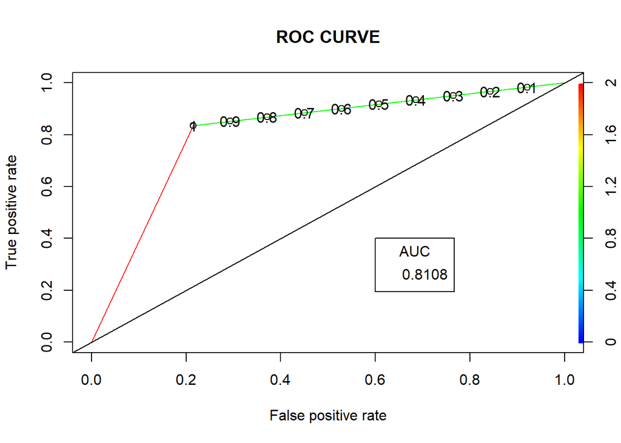

```r
ROCPred <- prediction(predict_reg, test_reg$winner)
ROCPer <- performance(ROCPred, measure = "tpr", x.measure = "fpr")
auc <- performance(ROCPred, measure = "auc")
auc <- auc@y.values[[1]]
# Plotting curve
plot(ROCPer, colorize = TRUE,
     print.cutoffs.at = seq(0.1, by = 0.1),
     main = "ROC CURVE")
abline(a = 0, b = 1)

auc <- round(auc, 4)
legend(.6, .4, auc, title = "AUC", cex = 1)
```

pretty good

```r
#Actual Data

idx_test_1_temp <- numric_data[seq(1, nrow(numric_data), by = 5),][1:17]

idx_train_1_temp <- numric_data[-seq(1, nrow(numric_data), by = 5),][1:17]



test_1_temp <- idx_test_1_temp[,-15]
training_1_temp <- idx_train_1_temp[,-15]

training_target_temp <- idx_train_1_temp[,15]

test_target_temp <- idx_test_1_temp[,15]
```

## now we going to predict if the movie succeeded in the same way:

```r
# Splitting dataset
set.seed(170)

split <- sample.split(numric_data, SplitRatio = 0.8)


train_reg <- subset(numric_data, split == "TRUE")
test_reg <- subset(numric_data, split == "FALSE")
```

check train split

```r
winners_train = numric_data %>% filter(succeed == 1)
los_train = train_reg %>% filter(succeed == 0)
nrow(winners_train)
```

```
## [1] 184
```

```r
nrow(los_train)
```

```
## [1] 2725
```

```r
nrow(los_train)/nrow(winners_train)
```

```
## [1] 14.80978
```

```r
winners_train$ntime = 14
winners_train = winners_train[rep(seq_len(nrow(winners_train)), winners_train$ntime),] ## duplicate rows
winners_train = subset(winners_train, select = -c(ntime) )
train_reg = rbind(winners_train , los_train)
```

```r
logistic_model <- glm(succeed ~ avg_act_gross + avg_dir_gross + cast_total_facebook_likes + duration + avg_act_rating + avg_dir_rating +ROI + director_facebook_likes + main_actor_facebook_likes + movie_facebook_likes + month ,data = train_reg, family = "binomial")
```

```r
# Summary
summary(logistic_model)$coef
```

```
##                                Estimate   Std. Error    z value      Pr(>|z|)
## (Intercept)               -1.800308e+01 6.684523e-01 -26.932480 9.151042e-160
## avg_act_gross              1.214734e-08 1.099693e-09  11.046111  2.289173e-28
## avg_dir_gross              1.105892e-08 9.010802e-10  12.272960  1.265415e-34
## cast_total_facebook_likes -8.763824e-06 5.783540e-06  -1.515305  1.296953e-01
## duration                   1.414450e-02 1.693254e-03   8.353444  6.630067e-17
## avg_act_rating             3.753025e-01 8.686734e-02   4.320409  1.557403e-05
## avg_dir_rating             1.697778e+00 9.585011e-02  17.712844  3.337752e-70
## ROI                        8.827630e-04 7.340113e-04   1.202656  2.291095e-01
## director_facebook_likes    5.212798e-05 9.768198e-06   5.336499  9.475837e-08
## main_actor_facebook_likes  1.239446e-05 7.620692e-06   1.626422  1.038599e-01
## movie_facebook_likes       8.550460e-06 1.398445e-06   6.114262  9.700473e-10
## month                     -7.119607e-02 1.105147e-02  -6.442228  1.177323e-10
```

```r
predict_reg <- predict(logistic_model, test_reg, type = "response")

# Changing probabilities - high threshold to be sure in our predictions
predict_reg <- ifelse(predict_reg >0.5, 1, 0)
```

```r
# Evaluating model accuracy
# using confusion matrix
table(test_reg$winner, predict_reg)
```

```
##    predict_reg
##       0   1
##   0 608  96
##   1  18  43
```

```r
missing_classerr <- mean(predict_reg != test_reg$winner)
print(paste('Accuracy =', 1 - missing_classerr))
```

```
## [1] "Accuracy = 0.850980392156863"
```

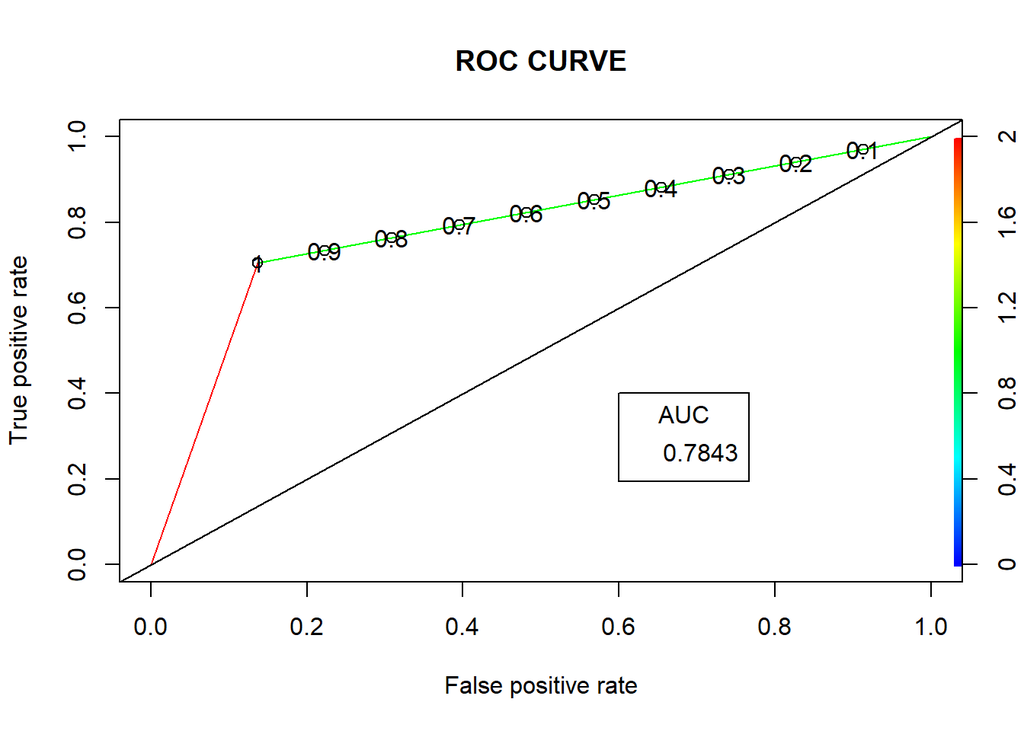

```r
ROCPred <- prediction(predict_reg, test_reg$winner)
ROCPer <- performance(ROCPred, measure = "tpr", x.measure = "fpr")
auc <- performance(ROCPred, measure = "auc")
auc <- auc@y.values[[1]]
# Plotting curve
plot(ROCPer, colorize = TRUE,
     print.cutoffs.at = seq(0.1, by = 0.1),
     main = "ROC CURVE")
abline(a = 0, b = 1)

auc <- round(auc, 4)
legend(.6, .4, auc, title = "AUC", cex = 1)
```

```r
classfic_df = movies
```

```r
summary(classfic_df$imdb_score)
```

```
##    Min. 1st Qu.  Median    Mean 3rd Qu.    Max.
##   1.600   5.900   6.600   6.492   7.200   9.300
```

```r
summary(classfic_df$gross)
```

```
##      Min.   1st Qu.    Median      Mean   3rd Qu.      Max.
##       162   6578799  27900000  51977444  66946021 760505847
```

```r
# "bad_R & bad_G"
movies$score_class[movies$imdb_score  < 6.600 & movies$gross < 27979400] <-1

movies$score_class[movies$imdb_score  >= 6.600 & movies$gross < 27979400] <-2

movies$score_class[movies$imdb_score  < 6.600 & movies$gross >= 27979400] <-3

movies$score_class[movies$imdb_score  >= 6.600 & movies$gross >= 27979400] <-4
```

```r
movies %>% group_by(score_class) %>% summarise(n = n())
```

```
## # A tibble: 4 x 2
##   score_class     n
##         <dbl> <int>
## 1           1   924
## 2           2   897
## 3           3   829
## 4           4   989
```

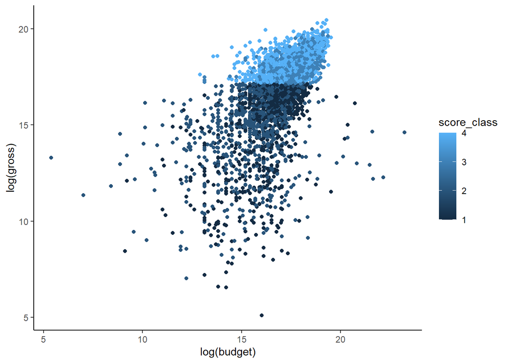

```r
ggplot(movies)+aes(y=log(gross),x=log(budget),color=score_class)+geom_point()+theme_classic()
```

*To be continued*